# Weight Lifting Exercise

# Summary

In this project, our goal is to use data from accelerometers on the belt, forearm, arm, and dumbell of 6 participants to predict the manner in which they did a unilateral dumbbell biceps curl: exactly to the specification (ClassA), throwing the elbows to the front (Class B), lifting the dumbbell only halfway (Class C), lowering the dumbbell only halfway (Class D), or throwing the hips to the front (Class E).

Given the highly irregular patterns in the data, we elect to use a random forest to predict the classes. After pre-processing the data to eliminate variables with near-zero variation and variables with many NA values, we estimate a random forest on all remaining covariates. With cross validation on a small test data set from our training data, we estimate out-of-sample error to be on the order of 1% or less, suggesting excellent predictive abilities.

# Data Analysis

Our first step is to split the data into a training set and a test set and do some exploratory analysis on the training set. We set the seed for reproducibility.

```r
set.seed(51688)
inTrain <- createDataPartition(y = move$classe,p = 0.7,list = FALSE)
training <- move[inTrain,]
testing <- move[-inTrain,]
```

As can be seen from the plot below (which is representative of other such plots of covariate versus class), there is considerable noise in the data, and it is not clear how to distinguish between classes based on any given covariate.

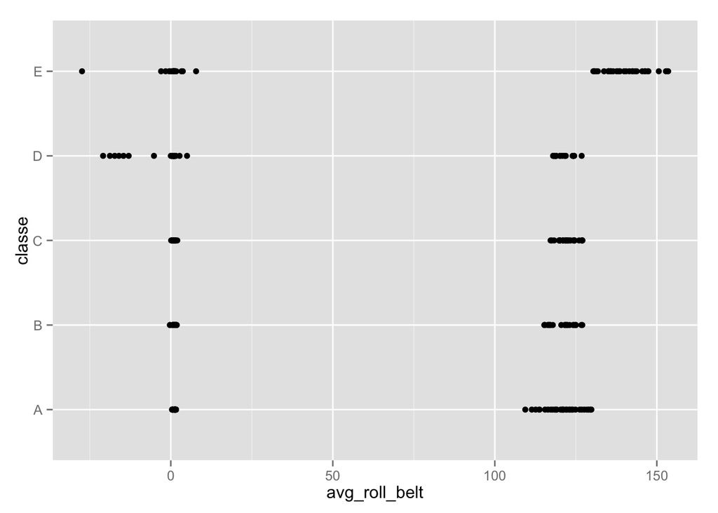

```r
qplot(avg_roll_belt,classe,data = training)
```

# Data Pre-Processing and Model Estimation

Due to the noisiness of the data, we choose to use a random forest to fit the training data, given its accuracy, even for “highly irregular patterns in data” (Wikipedia 2015). We first work to clean up the data a bit. First, we can remove the first seven variables, which deal with identification of the user and when the measurements were taken, as they will play no part in model formulation.

```r
training <- select(training,-(X:num_window))
```

Now, we can find covariates with zero, or near-zero variance and remove them. This will get rid of variables that do not differ much between observations and so would not be useful for prediction of class.

```r
zerovar <- nearZeroVar(training[,1:152],saveMetrics = TRUE)
remove <- names(training) %in% row.names(zerovar[zerovar$nzv,])
training <- training[,!remove]
```

Finally, we remove variables with many NA values, as they will not be useful in model prediction. By looking at the proportion of NA values in each column, we see that columns either have a high proportion of NA values (97.9%) or none, so we simply remove all covariates with any NA value.

```r
apply(training,MARGIN = 2,FUN = function(x) sum(is.na(x))/length(x))
```

```
##                roll_belt               pitch_belt                 yaw_belt
##                0.0000000                0.0000000                0.0000000
##         total_accel_belt            max_roll_belt           max_picth_belt
##                0.0000000                0.9786707                0.9786707
##            min_roll_belt           min_pitch_belt      amplitude_roll_belt
##                0.9786707                0.9786707                0.9786707
##     amplitude_pitch_belt     var_total_accel_belt            avg_roll_belt
##                0.9786707                0.9786707                0.9786707
##         stddev_roll_belt            var_roll_belt           avg_pitch_belt
##                0.9786707                0.9786707                0.9786707
##        stddev_pitch_belt           var_pitch_belt             avg_yaw_belt
##                0.9786707                0.9786707                0.9786707
##          stddev_yaw_belt             var_yaw_belt             gyros_belt_x
##                0.9786707                0.9786707                0.0000000
##             gyros_belt_y             gyros_belt_z             accel_belt_x
##                0.0000000                0.0000000                0.0000000
##             accel_belt_y             accel_belt_z            magnet_belt_x
##                0.0000000                0.0000000                0.0000000
##            magnet_belt_y            magnet_belt_z                 roll_arm
##                0.0000000                0.0000000                0.0000000
##                pitch_arm                  yaw_arm          total_accel_arm
##                0.0000000                0.0000000                0.0000000
##            var_accel_arm              gyros_arm_x              gyros_arm_y
##                0.9786707                0.0000000                0.0000000
##              gyros_arm_z              accel_arm_x              accel_arm_y
##                0.0000000                0.0000000                0.0000000
##              accel_arm_z             magnet_arm_x             magnet_arm_y
##                0.0000000                0.0000000                0.0000000
##             magnet_arm_z            max_picth_arm              max_yaw_arm
##                0.0000000                0.9786707                0.9786707
##              min_yaw_arm        amplitude_yaw_arm            roll_dumbbell
##                0.9786707                0.9786707                0.0000000
##           pitch_dumbbell             yaw_dumbbell        max_roll_dumbbell
##                0.0000000                0.0000000                0.9786707
##       max_picth_dumbbell        min_roll_dumbbell       min_pitch_dumbbell
##                0.9786707                0.9786707                0.9786707
##  amplitude_roll_dumbbell amplitude_pitch_dumbbell     total_accel_dumbbell
##                0.9786707                0.9786707                0.0000000
##       var_accel_dumbbell        avg_roll_dumbbell     stddev_roll_dumbbell
##                0.9786707                0.9786707                0.9786707
```

[output cut: 11 more lines]

```
##                0.0000000                0.0000000                0.0000000
##              yaw_forearm         max_roll_forearm        max_picth_forearm
##                0.0000000                0.9786707                0.9786707
##         min_roll_forearm        min_pitch_forearm   amplitude_roll_forearm
##                0.9786707                0.9786707                0.9786707
##  amplitude_pitch_forearm      total_accel_forearm        var_accel_forearm
##                0.9786707                0.0000000                0.9786707
##         avg_roll_forearm          gyros_forearm_x          gyros_forearm_y
##                0.9786707                0.0000000                0.0000000
##          gyros_forearm_z          accel_forearm_x          accel_forearm_y
##                0.0000000                0.0000000                0.0000000
##          accel_forearm_z         magnet_forearm_x         magnet_forearm_y
##                0.0000000                0.0000000                0.0000000
##         magnet_forearm_z                   classe
##                0.0000000                0.0000000
```

```r
training <- training[,apply(training,MARGIN = 2,FUN = function(x) !any(is.na(x)))]
```

Now we need to select the same columns in the testing data for cross-validation at a later point.

```r
testing <- testing[,names(training)]
```

Now, we can run a random forest model on the training data. We run a the random forest including all possible predictors. We run the risk of overfitting the training data in this way, but, as we will see in the cross validation, we do not appear to have issues of overfitting.

```r
model <- randomForest(classe~.,data = training)
```

# Prediction and Cross Validation

Now, with this model we can predict out-of-sample error by first predicting the class in the testing set and then calculating the confusion matrix.

```r
prediction <- predict(model,testing[,-ncol(testing)],type = "response")
confusionMatrix(prediction,testing$classe)
```

```
## Confusion Matrix and Statistics
##
##           Reference
## Prediction    A    B    C    D    E
##          A 1673    2    0    0    0
##          B    0 1137    4    0    0
##          C    0    0 1021    8    0
##          D    0    0    1  956    2
##          E    1    0    0    0 1080
##
## Overall Statistics
##
##                Accuracy : 0.9969
##                  95% CI : (0.9952, 0.9982)
##     No Information Rate : 0.2845
##     P-Value [Acc > NIR] : < 2.2e-16
##
##                   Kappa : 0.9961
##  Mcnemar's Test P-Value : NA
##
## Statistics by Class:
##
##                      Class: A Class: B Class: C Class: D Class: E
## Sensitivity            0.9994   0.9982   0.9951   0.9917   0.9982
## Specificity            0.9995   0.9992   0.9984   0.9994   0.9998
## Pos Pred Value         0.9988   0.9965   0.9922   0.9969   0.9991
## Neg Pred Value         0.9998   0.9996   0.9990   0.9984   0.9996
## Prevalence             0.2845   0.1935   0.1743   0.1638   0.1839
## Detection Rate         0.2843   0.1932   0.1735   0.1624   0.1835
## Detection Prevalence   0.2846   0.1939   0.1749   0.1630   0.1837
## Balanced Accuracy      0.9995   0.9987   0.9967   0.9955   0.9990
```

Therefore, we predict an accuracy of about 99% overall. This suggests an out-of-sample error rate of about 1% or less. It looks like, from the confusion matrix, that classes C and D are the least well separated, which makes sense given the nature of those movements (C is lift only halfway and D is lower only halfway).